# Advanced statistics for physics analysis - Exercise 1

Matteo Bortoletto

15/2/2020

## Exercise 1

1. The table gives the volume, area, length and maximum and mean depths of some Scottish lakes. Create vectors, holding the lake’s name and all the parameters and build a dataframe called `scottish.lakes` from the vectors.

```r
name <- c("Loch Ness", "Loch Lomond", "Loch Morar", "Loch Tay", "Loch Awe", "Loch Maree",
          "Loch Ericht", "Loch Lochy", "Loch Rannoch", "Loch Shiel", "Loch Katrine", "Loch Arkaig", "Loch Shin")
volume <- c(7.45, 2.6, 2.3, 1.6, 1.2, 1.09, 1.08, 1.07, 0.97, 0.79, 0.77, 0.75, 0.35)
area <- c(56, 71, 27, 26.4, 39, 28.6, 18.6, 16, 19, 19.5, 12.4, 16, 22.5)
lenght <- c(39, 36, 18.8, 23, 41, 20, 23, 16, 15.7, 28, 12.9, 19.3, 27.8)
MaxDepth <- c(230, 190, 310, 150, 94, 114, 156, 162, 134, 128, 151, 109, 49)
MeanDepth <- c(132, 37, 87, 60.6, 32, 38, 57.6, 70, 51, 40, 43.4, 46.5, 15.5)

scottish.lakes <- data.frame(name, volume, area, lenght, MaxDepth, MeanDepth)

scottish.lakes
```

```
##            name volume area lenght MaxDepth MeanDepth
## 1     Loch Ness   7.45 56.0   39.0      230     132.0
## 2   Loch Lomond   2.60 71.0   36.0      190      37.0
## 3    Loch Morar   2.30 27.0   18.8      310      87.0
## 4      Loch Tay   1.60 26.4   23.0      150      60.6
## 5      Loch Awe   1.20 39.0   41.0       94      32.0
## 6    Loch Maree   1.09 28.6   20.0      114      38.0
## 7   Loch Ericht   1.08 18.6   23.0      156      57.6
## 8    Loch Lochy   1.07 16.0   16.0      162      70.0
## 9  Loch Rannoch   0.97 19.0   15.7      134      51.0
## 10   Loch Shiel   0.79 19.5   28.0      128      40.0
## 11 Loch Katrine   0.77 12.4   12.9      151      43.4
## 12  Loch Arkaig   0.75 16.0   19.3      109      46.5
## 13    Loch Shin   0.35 22.5   27.8       49      15.5
```

2. Order the frame with respect to the area and determine the two largest area lakes.

```r
scottish.lakes[which.max(scottish.lakes$volume),]
```

```
##        name volume area lenght MaxDepth MeanDepth
## 1 Loch Ness   7.45   56     39      230       132
```

```r
scottish.lakes[which.min(scottish.lakes$volume),]
```

```
##         name volume area lenght MaxDepth MeanDepth
## 13 Loch Shin   0.35 22.5   27.8       49      15.5
```

```r
scottish.lakes[which.max(scottish.lakes$area),]
```

```
##          name volume area lenght MaxDepth MeanDepth
## 2 Loch Lomond    2.6   71     36      190        37
```

```r
scottish.lakes[which.min(scottish.lakes$area),]
```

```
##            name volume area lenght MaxDepth MeanDepth
## 11 Loch Katrine   0.77 12.4   12.9      151      43.4
```

```r
scottish.lakes[order(area),]
```

```
##            name volume area lenght MaxDepth MeanDepth
## 11 Loch Katrine   0.77 12.4   12.9      151      43.4
## 8    Loch Lochy   1.07 16.0   16.0      162      70.0
## 12  Loch Arkaig   0.75 16.0   19.3      109      46.5
## 7   Loch Ericht   1.08 18.6   23.0      156      57.6
## 9  Loch Rannoch   0.97 19.0   15.7      134      51.0
## 10   Loch Shiel   0.79 19.5   28.0      128      40.0
## 13    Loch Shin   0.35 22.5   27.8       49      15.5
## 4      Loch Tay   1.60 26.4   23.0      150      60.6
## 3    Loch Morar   2.30 27.0   18.8      310      87.0
## 6    Loch Maree   1.09 28.6   20.0      114      38.0
## 5      Loch Awe   1.20 39.0   41.0       94      32.0
## 1     Loch Ness   7.45 56.0   39.0      230     132.0
## 2   Loch Lomond   2.60 71.0   36.0      190      37.0
```

3. By summing up the areas occpupied by the lakes, determine the area of Scotland covered by water.

```r
TotArea <- sum(scottish.lakes$area)
TotArea
```

```
## [1] 372
```

## Exercise 2

Install and load the `DAAG` and the `tibble` packages.

```r
library("DAAG")
library("tibble")
```

Get information on the package content and on the ais data frame.

```r
?ais
```

Create a `tibble` from the `ais data.frame`.

```r
data <- as_tibble(ais)
data
```

```
## # A tibble: 202 x 13
##      rcc   wcc    hc    hg  ferr   bmi   ssf pcBfat   lbm    ht    wt sex
##    <dbl> <dbl> <dbl> <dbl> <dbl> <dbl> <dbl>  <dbl> <dbl> <dbl> <dbl> <fct>
##  1  3.96   7.5  37.5  12.3    60  20.6 109.    19.8  63.3  196.  78.9 f
##  2  4.41   8.3  38.2  12.7    68  20.7 103.    21.3  58.6  190.  74.4 f
##  3  4.14   5    36.4  11.6    21  21.9 105.    19.9  55.4  178.  69.1 f
##  4  4.11   5.3  37.3  12.6    69  21.9 126.    23.7  57.2  185   74.9 f
##  5  4.45   6.8  41.5  14      29  19.0  80.3   17.6  53.2  185.  64.6 f
##  6  4.1    4.4  37.4  12.5    42  21.0  75.2   15.6  53.8  174   63.7 f
##  7  4.31   5.3  39.6  12.8    73  21.7  87.2   20.0  60.2  186.  75.2 f
##  8  4.42   5.7  39.9  13.2    44  20.6  97.9   22.4  48.3  174.  62.3 f
##  9  4.3    8.9  41.1  13.5    41  22.6  75.1   18.0  54.6  171.  66.5 f
## 10  4.51   4.4  41.6  12.7    44  19.4  65.1   15.1  53.4  180.  62.9 f
## # … with 192 more rows, and 1 more variable: sport <fct>
```

1. Create a table grouping the data by gender and by sport; produce a barplot with the table adding a legend.

```r
library("wesanderson")
dt = table(data$sex, data$sport)
dt
```

```
##
##     B_Ball Field Gym Netball Row Swim T_400m T_Sprnt Tennis W_Polo
##   f     13     7   4      23  22    9     11       4      7      0
##   m     12    12   0       0  15   13     18      11      4     17
```

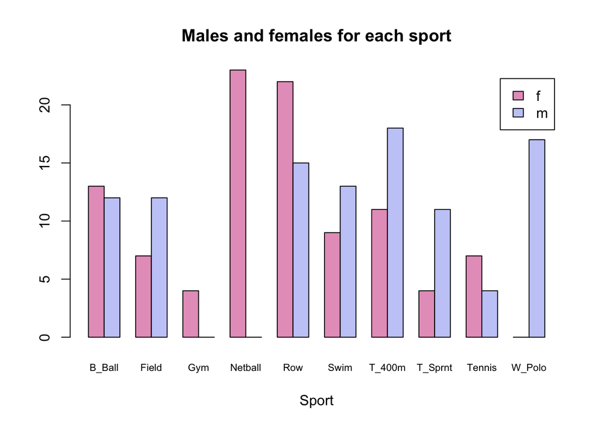

```r
barplot(dt,
        main="Males and females for each sport",
        xlab="Sport",
        col= wes_palette("GrandBudapest2", n = 2),
        legend = rownames(dt),
        beside=TRUE,
        cex.names=.7)
```

2. Determine if any of the columns holds missing values.

```r
any(is.na(data))
```

```
## [1] FALSE
```

3. Produce boxplots of the main blood variables (’red blood cell counts’, ’white blood cell counts’, ’hematocrit’ and ’hemaglobin concentration’), for different kind of sports.

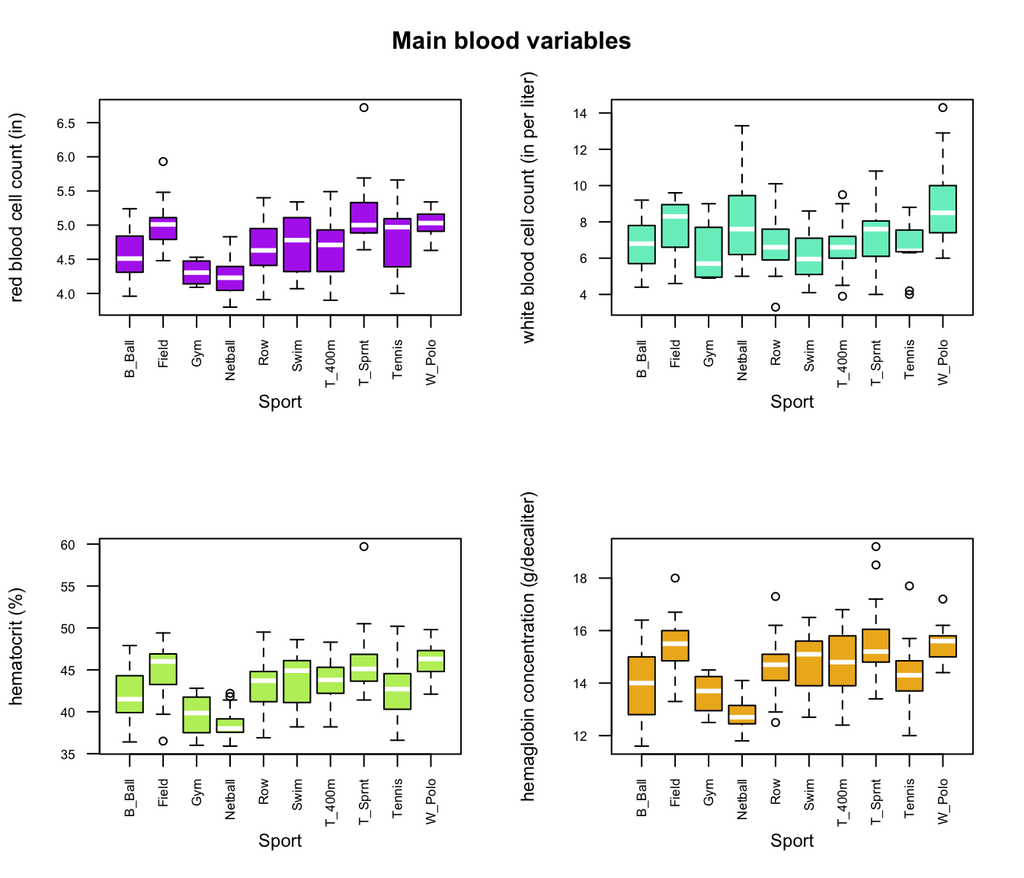

```r
par(mfrow=c(2,2))
boxplot(rcc ~ sport, data = ais ,
        ylab = "red blood cell count (in)" , xlab = "Sport",
        col = "darkorchid2", medcol = "white", las=2, cex.axis=.65, cex.lab=0.9)
boxplot(wcc ~ sport, data = ais ,
        ylab = "white blood cell count (in per liter)" , xlab = "Sport",
        col = "aquamarine2", medcol = "white", las=2, cex.axis=.65, cex.lab=0.9)
boxplot(hc ~ sport, data = ais ,
        ylab = "hematocrit (%)" , xlab = "Sport",
        col = "darkolivegreen2", medcol = "white", las=2, cex.axis=.65, cex.lab=0.9)
boxplot(hg ~ sport, data = ais ,
        ylab = "hemaglobin concentration (g/decaliter)" , xlab = "Sport",
        col = "goldenrod2", medcol = "white", las=2, cex.axis=.65, cex.lab=0.9)
title("Main blood variables", outer = TRUE, line = -2)
```

4. Make some scatter plot correlations of the same blood variables using different colors and symbols for the two genders in the sample.

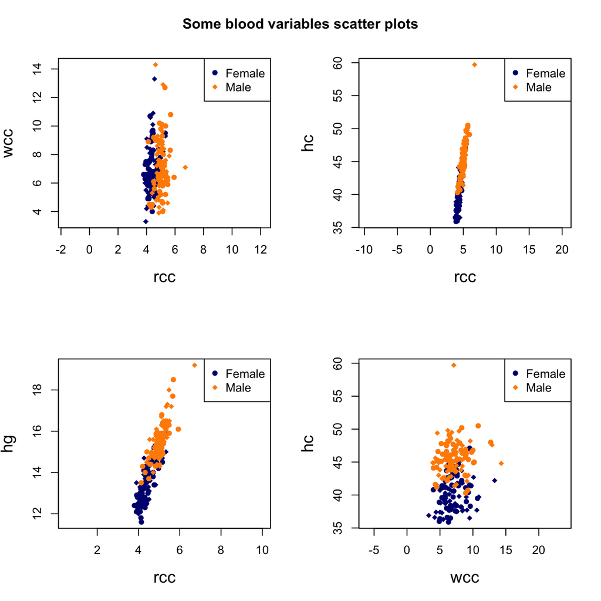

```r
# non faccio tutti i possibili scatter plot, solo alcuni
p_area <- matrix(c(1, 2, 3, 4), nrow=2, ncol=2, byrow=TRUE)
layout(p_area)
par(cex.lab=1.4)
par(cex.sub = 1.4)
plot(data$rcc, data$wcc, pch = c(16,18),
     col = ifelse(data$sex == "f", "navy", "darkorange"), asp = 1,
     xlab = "rcc", ylab = "wcc")
legend('topright', c('Female', 'Male'), pch=c(16,18), col = c('navy','darkorange'), cex = 1)
plot(data$rcc, data$hc, pch = c(16,18),
     col = ifelse(data$sex == "f", "navy", "darkorange"), asp = 1,
     xlab = "rcc", ylab = "hc")
legend('topright', c('Female', 'Male'), pch=c(16,18), col = c('navy','darkorange'), cex = 1)
plot(data$rcc, data$hg, pch = c(16,18),
     col = ifelse(data$sex == "f", "navy", "darkorange"), asp = 1,
     xlab = "rcc", ylab = "hg")
legend('topright', c('Female', 'Male'), pch=c(16,18), col = c('navy','darkorange'), cex = 1)
plot(data$wcc, data$hc, pch = c(16,18),
     col = ifelse(data$sex == "f", "navy", "darkorange"), asp = 1,
     xlab = "wcc", ylab = "hc")
legend('topright', c('Female', 'Male'), pch=c(16,18), col = c('navy','darkorange'), cex = 1)
title("Some blood variables scatter plots", outer = TRUE, line = -2)
```

## Exercise 3

Download the latest update on the COVID-19 Virus infection fom the European Centers for Disease Control.

```r
needed_packages <- c('lubridate','readxl', 'curl')
already_installed <- needed_packages %in% installed.packages()
for (pack in needed_packages [!already_installed]) {
  message (paste("To be installed :", pack , sep =" "))
  install.packages(pack)
}
library (lubridate)
```

```r
library (readxl)
library (curl)
url <- "https://www.ecdc.europa.eu/sites/default/files/documents/"
fname <- "COVID-19-geographic-disbtribution-worldwide-"
date <- lubridate::today() - 1
ext = ".xlsx"
target <- paste(url, fname, date, ext, sep ="")
message ("target: ", target)
```

```
## target: https://www.ecdc.europa.eu/sites/default/files/documents/COVID-19-geographic-disbtribution-worldwide-2020-04-12.xlsx
```

```r
tmp_file <- tempfile("data", "/tmp", fileext = ext)
tmp <- curl::curl_download(target, destfile = tmp_file)
covid <- readxl::read_xlsx(tmp_file)
```

1. Examine the loaded tibble structure.

```r
covid
```

```
## # A tibble: 10,332 x 10
##    dateRep               day month  year cases deaths countriesAndTer… geoId
##    <dttm>              <dbl> <dbl> <dbl> <dbl>  <dbl> <chr>            <chr>
##  1 2020-04-12 00:00:00    12     4  2020    34      3 Afghanistan      AF
##  2 2020-04-11 00:00:00    11     4  2020    37      0 Afghanistan      AF
##  3 2020-04-10 00:00:00    10     4  2020    61      1 Afghanistan      AF
##  4 2020-04-09 00:00:00     9     4  2020    56      3 Afghanistan      AF
##  5 2020-04-08 00:00:00     8     4  2020    30      4 Afghanistan      AF
##  6 2020-04-07 00:00:00     7     4  2020    38      0 Afghanistan      AF
##  7 2020-04-06 00:00:00     6     4  2020    29      2 Afghanistan      AF
##  8 2020-04-05 00:00:00     5     4  2020    35      1 Afghanistan      AF
##  9 2020-04-04 00:00:00     4     4  2020     0      0 Afghanistan      AF
## 10 2020-04-03 00:00:00     3     4  2020    43      0 Afghanistan      AF
## # … with 10,322 more rows, and 2 more variables: countryterritoryCode <chr>,
## #   popData2018 <dbl>
```

2. Create a sub-tibble containing only the last day and produce a table with all the countries with number of deaths or number of new cases greater than 200.

```r
lastDay <- subset(covid, dateRep==lubridate::today() - 1)
lastDay
```

```
## # A tibble: 205 x 10
##    dateRep               day month  year cases deaths countriesAndTer… geoId
##    <dttm>              <dbl> <dbl> <dbl> <dbl>  <dbl> <chr>            <chr>
##  1 2020-04-12 00:00:00    12     4  2020    34      3 Afghanistan      AF
##  2 2020-04-12 00:00:00    12     4  2020    17      0 Albania          AL
##  3 2020-04-12 00:00:00    12     4  2020    64     19 Algeria          DZ
##  4 2020-04-12 00:00:00    12     4  2020    21      2 Andorra          AD
##  5 2020-04-12 00:00:00    12     4  2020     0      0 Angola           AO
##  6 2020-04-12 00:00:00    12     4  2020     0      0 Anguilla         AI
##  7 2020-04-12 00:00:00    12     4  2020     0      0 Antigua_and_Bar… AG
##  8 2020-04-12 00:00:00    12     4  2020   162      7 Argentina        AR
##  9 2020-04-12 00:00:00    12     4  2020    30      2 Armenia          AM
## 10 2020-04-12 00:00:00    12     4  2020     6      0 Aruba            AW
## # … with 195 more rows, and 2 more variables: countryterritoryCode <chr>,
## #   popData2018 <dbl>
```

```r
df <- lastDay[lastDay[, "cases"] > 200 & lastDay[, "deaths"] > 200,]
df
```

```
## # A tibble: 6 x 10
##   dateRep               day month  year cases deaths countriesAndTer… geoId
##   <dttm>              <dbl> <dbl> <dbl> <dbl>  <dbl> <chr>            <chr>
## 1 2020-04-12 00:00:00    12     4  2020  1351    327 Belgium          BE
## 2 2020-04-12 00:00:00    12     4  2020  3114    635 France           FR
## 3 2020-04-12 00:00:00    12     4  2020  4694    619 Italy            IT
## 4 2020-04-12 00:00:00    12     4  2020  4830    510 Spain            ES
## 5 2020-04-12 00:00:00    12     4  2020  8719    917 United_Kingdom   UK
## 6 2020-04-12 00:00:00    12     4  2020 28391   1831 United_States_o… US
## # … with 2 more variables: countryterritoryCode <chr>, popData2018 <dbl>
```

3. Select the top 10 countries, in terms of cases, and plot the total number of cases as a function of time. Plot the total number of deaths as a function of time. In order to compare the different curves, normalize the first date-time plot to the same $t_0$ value.

```r
covid <- covid[order(-covid$cases),]
topCases <- covid[!duplicated(covid$countriesAndTerritories),]
top10cases <- topCases[1:10,]
top10cases
```

```
## # A tibble: 10 x 10
##    dateRep               day month  year cases deaths countriesAndTer… geoId
##    <dttm>              <dbl> <dbl> <dbl> <dbl>  <dbl> <chr>            <chr>
##  1 2020-04-11 00:00:00    11     4  2020 35527   2087 United_States_o… US
##  2 2020-02-13 00:00:00    13     2  2020 15141    254 China            CN
##  3 2020-04-01 00:00:00     1     4  2020  9222    849 Spain            ES
##  4 2020-04-12 00:00:00    12     4  2020  8719    917 United_Kingdom   UK
##  5 2020-04-01 00:00:00     1     4  2020  7578    499 France           FR
##  6 2020-03-22 00:00:00    22     3  2020  6557    795 Italy            IT
##  7 2020-03-28 00:00:00    28     3  2020  6294     72 Germany          DE
##  8 2020-04-05 00:00:00     5     4  2020  5275    292 Iran             IR
##  9 2020-04-12 00:00:00    12     4  2020  5138     95 Turkey           TR
## 10 2020-04-09 00:00:00     9     4  2020  2210    133 Brazil           BR
## # … with 2 more variables: countryterritoryCode <chr>, popData2018 <dbl>
```

```r
covidC <- covid[order(covid$dateRep),]
covidC <- covidC[covidC$countriesAndTerritories %in% top10cases$countriesAndTerritories,]
covidC
```

```
## # A tibble: 963 x 10
##    dateRep               day month  year cases deaths countriesAndTer… geoId
##    <dttm>              <dbl> <dbl> <dbl> <dbl>  <dbl> <chr>            <chr>
##  1 2019-12-31 00:00:00    31    12  2019    27      0 China            CN
##  2 2019-12-31 00:00:00    31    12  2019     0      0 Brazil           BR
##  3 2019-12-31 00:00:00    31    12  2019     0      0 France           FR
##  4 2019-12-31 00:00:00    31    12  2019     0      0 Germany          DE
##  5 2019-12-31 00:00:00    31    12  2019     0      0 Iran             IR
##  6 2019-12-31 00:00:00    31    12  2019     0      0 Italy            IT
##  7 2019-12-31 00:00:00    31    12  2019     0      0 Spain            ES
##  8 2019-12-31 00:00:00    31    12  2019     0      0 United_Kingdom   UK
##  9 2019-12-31 00:00:00    31    12  2019     0      0 United_States_o… US
## 10 2020-01-01 00:00:00     1     1  2020     0      0 Brazil           BR
## # … with 953 more rows, and 2 more variables: countryterritoryCode <chr>,
## #   popData2018 <dbl>
```

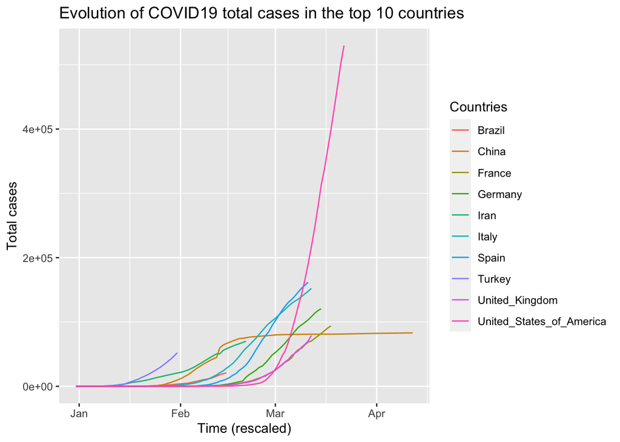

```r
covidC$cum_cases <- ave(covidC$cases, covidC$countriesAndTerritories,FUN=cumsum)
covidC$cum_deaths <- ave(covidC$deaths,covidC$countriesAndTerritories,FUN=cumsum)
covidC <- covidC[covidC$cum_cases != 0,]
t0 <- covidC$dateRep[1]

for (c in covidC$countriesAndTerritories){
  x <- covidC[covidC$countriesAndTerritories == c, 1]
  x <- x - as.integer(x[1,1]) + as.integer(t0)
  covidC[covidC$countriesAndTerritories == c, 1] <- x
}


library(ggplot2)

cases_plt <- ggplot(covidC,
                    aes(dateRep, cum_cases, colour=countriesAndTerritories)) +
             geom_line(aes(color=countriesAndTerritories)) +
             labs(colour = "Countries",
                  x = "Time (rescaled)",
                  y = "Total cases",
                  title = "Evolution of COVID19 total cases in the top 10 countries")

deaths_plt <- ggplot(covidC,
                     aes(dateRep, cum_deaths, colour=countriesAndTerritories)) +
              geom_line(aes(color=countriesAndTerritories)) +
              labs(colour = "Countries",
                   x = "Time (rescaled)",
                   y = "Total deaths",
                   title = "Evolution of COVID19 total deaths in the top 10 countries")
cases_plt
```

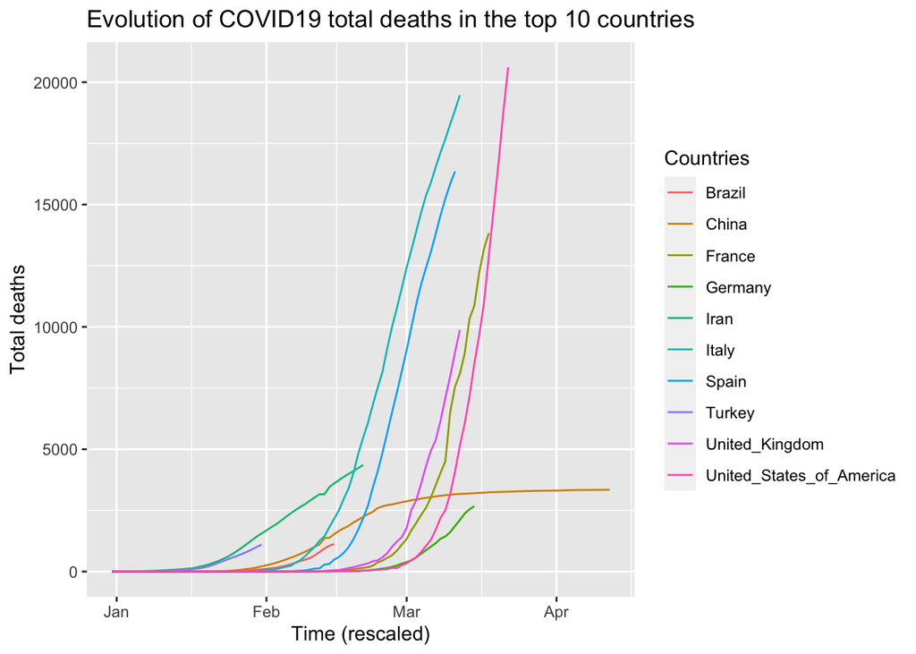

```r
deaths_plt
```